# Part II - (Loan Data from Prosper Exploration)

## by (Abdulraqib Omotosho)

## Investigation Overview

For the presentation, my objective focused on the exploration of the individual features of interest to discover the relationship between the borrowers and the loans they took and other correlations between various variables in the dataset.

## Dataset Overview

The dataset I will be using for this exploration is the Loan Data from Prosper gotten from Udacity’s curated datasets. This dataset contains 113,937 loans with 81 variables on each loan, including loan amount, borrower rate (or interest rate), current loan status, borrower income, and many others

## Distribution of Loan Status

exploring the statuses of loans that were took.

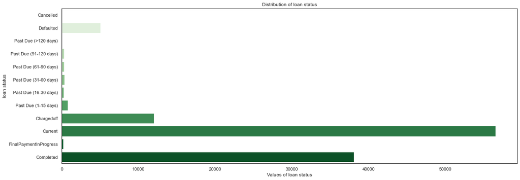

## Distribution of States

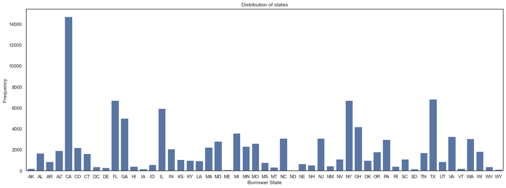

## Distribution of Income Range

Exploring the distribution of Income range. It can be seen that the majority of the borrowers had an income range between $25,000-74,999

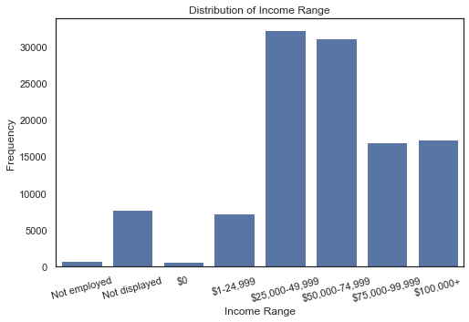

## Distribution of Employment Status

Exploring the distribution of Employment Status. This distribution shows that the majority of the borrowers are Employed and Full-time.

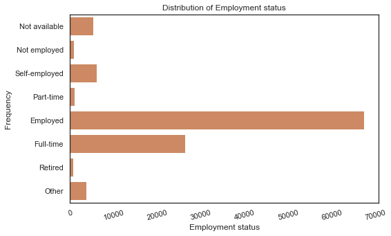

## Distribution of Stated Monthly Income

Exploring the distribution of Stated Monthly Income. This distribution shows that the stated monthly income of the borrowers is highly positively skewed.

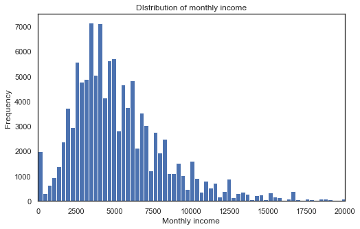

## Distribution of Listing Category

Exploring the distribution of Listing Category. This distribution shows that the a vast majority applied for debt consolidation loans.

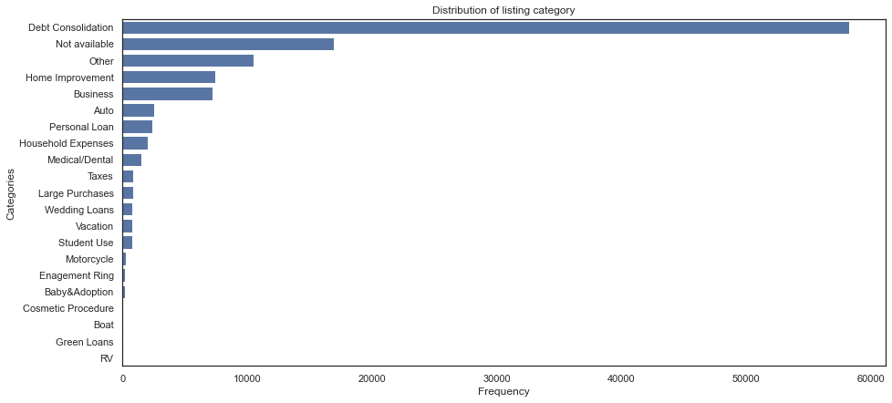

## Correlation between numeric variables in the dataset.

Exploring the correlation between numeric features in the dataset with the use of an heatmap. The plot shows that BorrowerAPR and BorrowerRate have a very high correlation. Investors also have a correlation of 0.38 with LoanOriginalAmount.

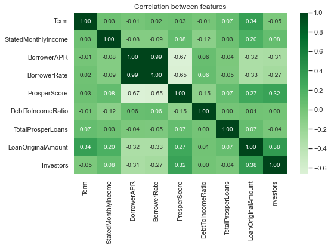

## Correlation between years and LoanOriginalAMount

Exploring the correlation between years and LoanOriginalAmount. The distribution shows that there is a positive correlation between Year and LoanOriginalAmount

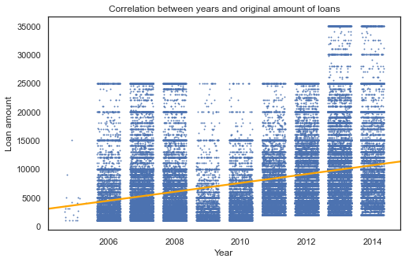

## Relationship between BorrowerRate and LoanOriginalAmount

Exploring the relationship between BorrowerRate and LoanOriginalAmount. The distribution shows that the range of BorrowerRate decreases with an increase of loan amount.

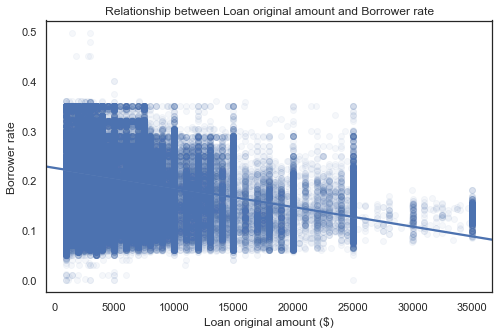

## Relationship between TotalProsperLoans Vs Month

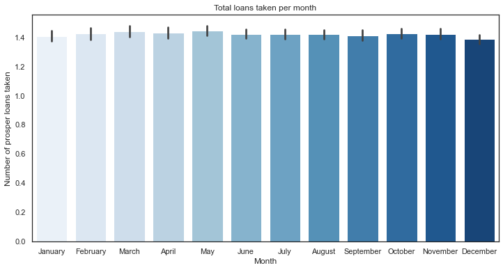

## Relationship between some Categorical features and Numeric features

Exploring the correlation between EmploymentStatus, IncomeRange, Year and LoanOriginalAmount, BorrowerRate, TotalProsperLoans. From the distribution, IncomeRange and LoanOriginalAMount are positively correlated.

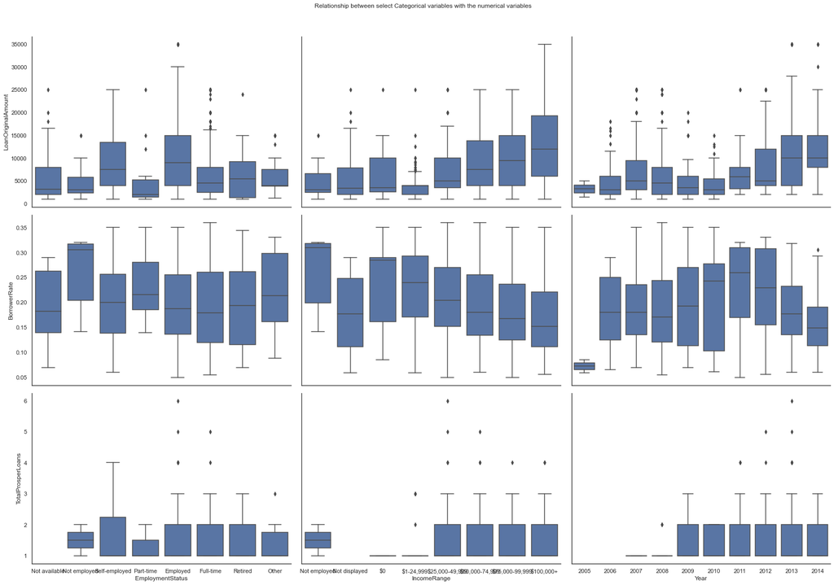